# team.Rmd

Taylor Turner, Ryan Lode, Molly Carrick

9/10/2020

## Team Rmd

```r
choco <- read.csv("https://raw.githubusercontent.com/xdaiISU/ds202materials/master/hwlabs/data/choco.csv")
```

1. From the histogram, it is clear that the distribution of ratings is skewed to the left-meaning that the mojority of ratings are on the higher end of the spectrum. Based on the boxplot, the median value appears to be around 3.25. There are a few outliers. It appears that there are four outliers, all on the low end of ratings, with the lowest one being a rating of 1.0.

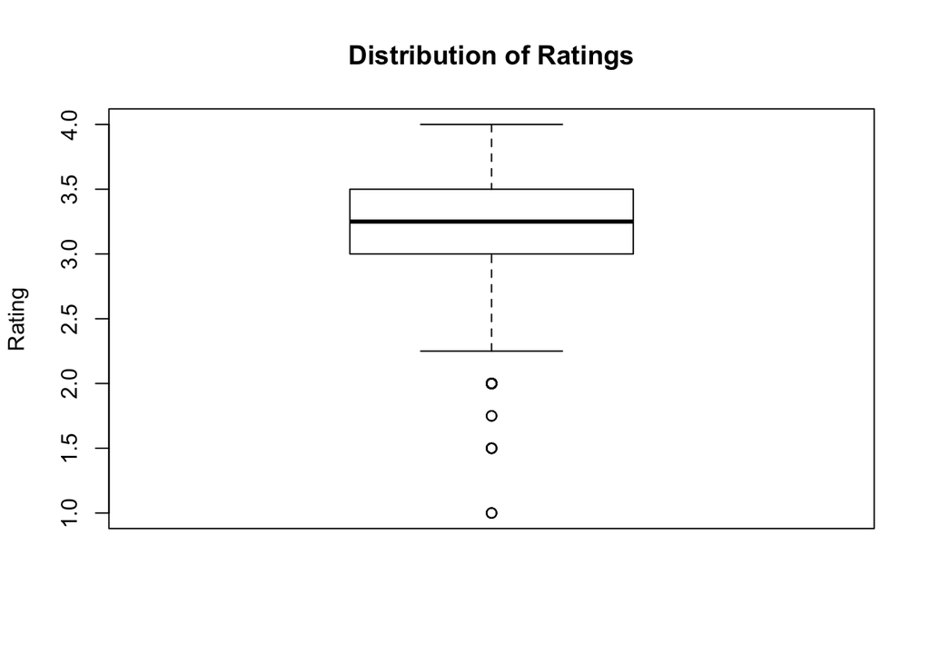

```r
boxplot(choco$Rating, main="Distribution of Ratings", ylab="Rating")
```

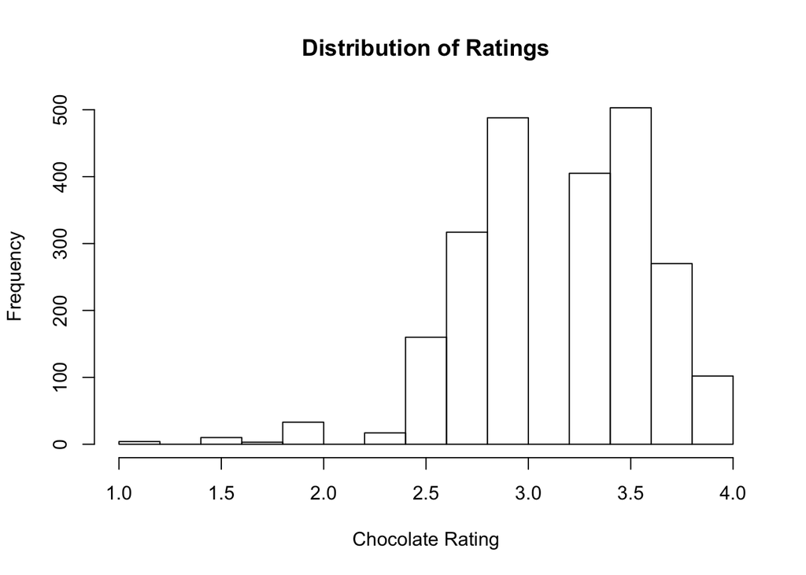

```r
hist(choco$Rating, main="Distribution of Ratings", xlab="Chocolate Rating")
```

2. It can be seen in the barplot that 2015 had the most ratings that year, while 2006 has the least. 2020 technically has the least, but I would argue that since 2020 is not yet over, that number is not definite yet.

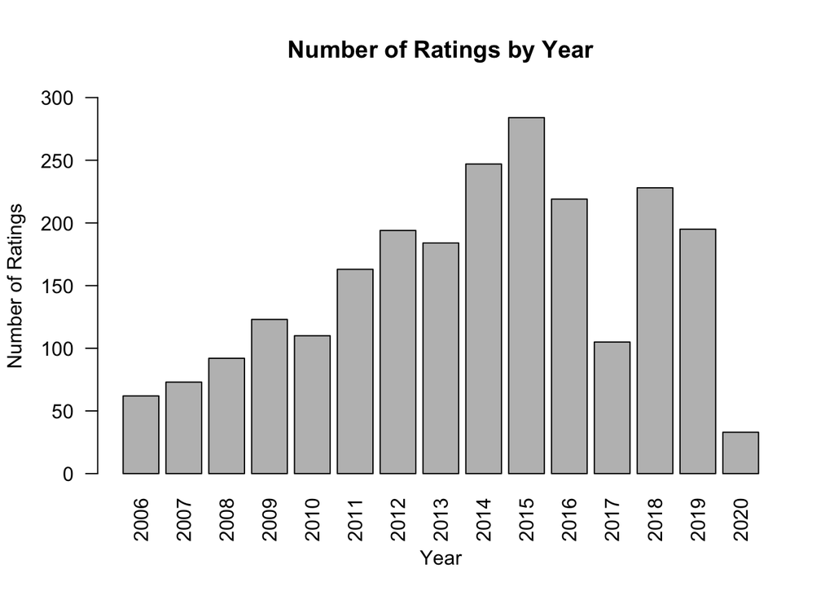

```r
chocoYears <- factor(choco$Date, levels = c(2006:2020))
barplot(table(chocoYears), xlab = 'Year', ylab = 'Number of Ratings', main = 'Number of Ratings by Year', ylim = c(0,300), las = 2)
```

3. From the scatterplot, there doesn’t seem to much of a correlation between cocoa percentage and rating. In general, cocoa percentages that are more mid-range rather than extreme seem to have higher ratings.

```r
percent <- choco[c("Cocoa_Percent","Rating")]
summary(percent)
```

```
##  Cocoa_Percent        Rating
##  Min.   : 42.00   Min.   :1.000
##  1st Qu.: 70.00   1st Qu.:3.000
##  Median : 70.00   Median :3.250
##  Mean   : 71.65   Mean   :3.184
##  3rd Qu.: 75.00   3rd Qu.:3.500
##  Max.   :100.00   Max.   :4.000
```

```r
str(percent)
```

```
## 'data.frame':    2312 obs. of  2 variables:
##  $ Cocoa_Percent: num  76 76 76 63 70 70 63 70 70 70 ...
##  $ Rating       : num  3.75 3.5 3.25 3.75 3.5 4 4 3.75 3.5 3.25 ...
```

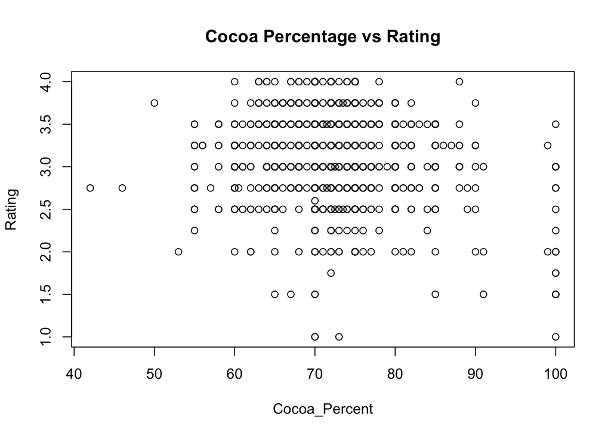

```r
plot(percent)
title(main="Cocoa Percentage vs Rating")
```

4.How do different characteristics of the chocolate compare? To elaborate, which characteristics tend to be more favorable and which ones are not? Create both numerical and graphical summaries, and explain.

**Analysis** In this analysis, I first sorted the characteristics in decreasing order, starting with the characteristic with the most entries and so on. I then created a chart with a series of boxplots showing the distribution of the ratings of chocolate bars versus their ratings. Each boxplot is arranged by decreasing median value. Based on the boxplots, Creamy and rich cocoa were the primary characteristics associated with a higher rating. However, creamy had more entries than ‘rich cocoa’. Interestingly, chocolate bars with the primary characterstic of being sweet had the lowest median value of those shown in the plot.

```r
choco$Characteristics1 = as.factor(choco$Characteristics1)
head(sort(table(choco$Characteristics1), decreasing = TRUE), n = 20)
```

```
##
##     creamy      sandy    intense      nutty      fatty      sweet     sticky
##        162        134         82         78         76         74         63
##        dry      spicy     gritty       oily     roasty     floral     earthy
##         58         56         55         50         49         48         38
##      cocoa   molasses    complex rich cocoa     smooth     grassy
##         37         33         26         23         23         22
```

```r
choco.flavorSub = choco[choco$Characteristics1 %in% c('creamy', 'sandy', 'intense','nuty','fatty','sweet',
                                                      'spicy', 'oily' ,'roasty', 'rich cocoa'),]

choco.flavorSub$Test = as.character(choco.flavorSub$Characteristics1)
choco.flavorSub$Test = as.factor(choco.flavorSub$Test)
```

```r
reorder(choco.flavorSub$Test, choco.flavorSub$Rating, FUN = median, na.rm = TRUE)
```

```r
choco.flavorSub$Test2 = ordered(choco.flavorSub$Test, levels = c('creamy','rich cocoa','spicy','intense',
                                                                 'oily','fatty','roasty','sandy','sweet'))
```

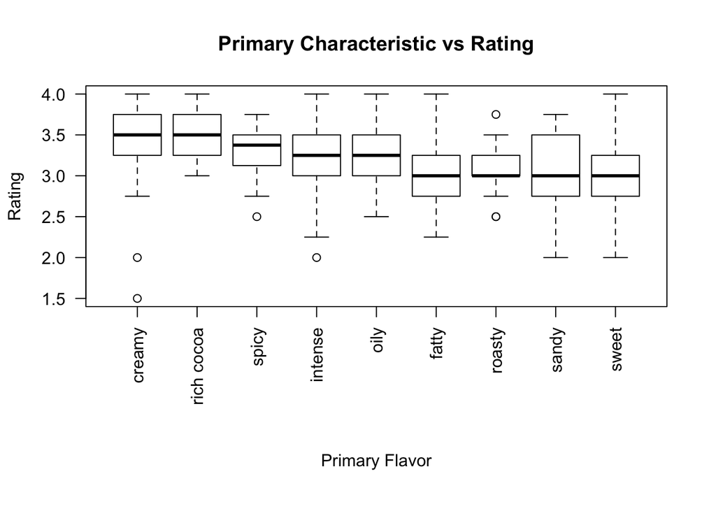

```r
par(mar=c(10, 4.2, 4.2, 2.4))
boxplot(choco.flavorSub$Rating ~ choco.flavorSub$Test2, xlab = '', ylab = 'Rating', main = 'Primary Characteristic vs Rating', las = 2)
mtext(text = 'Primary Flavor',side=1, line= 7.0)
```

```r
summary(choco$Rating[choco$Characteristics1 == 'acidic'])
```

```
##    Min. 1st Qu.  Median    Mean 3rd Qu.    Max.
##   1.500   2.500   3.000   2.722   3.250   3.500
```

```r
summary(choco$Rating[choco$Characteristics1 == 'chalky'])
```

```
##    Min. 1st Qu.  Median    Mean 3rd Qu.    Max.
##   1.000   2.500   3.000   2.714   3.000   3.250
```

```r
summary(choco$Rating[choco$Characteristics1 == 'unrefined'])
```

```
##    Min. 1st Qu.  Median    Mean 3rd Qu.    Max.
##   2.000   2.688   2.750   2.792   3.000   3.250
```

5.Brainstorm two analyses you would like to perform with your teammate. Describe in plain language what comparisons are you making. Create suitable numerical and graphical summaries for your analyses. Describe the results.

**Analysis 1:** The analysis I made from this data is comparing the ratings of the chocolate to the bean origin and seeing which origin of bean gives the highest ratings. From my barplot, we can see that Venezuela has the most instances of 4.0 rating with 18 data entries. When making this analysis I decided to just look at the top rated chocolates so I only looked at data entries that had a 4.0 rating.

```r
origin <- choco[c("Bean_Origin", "Rating")]
topO <- origin[origin$Rating == 4,]
```

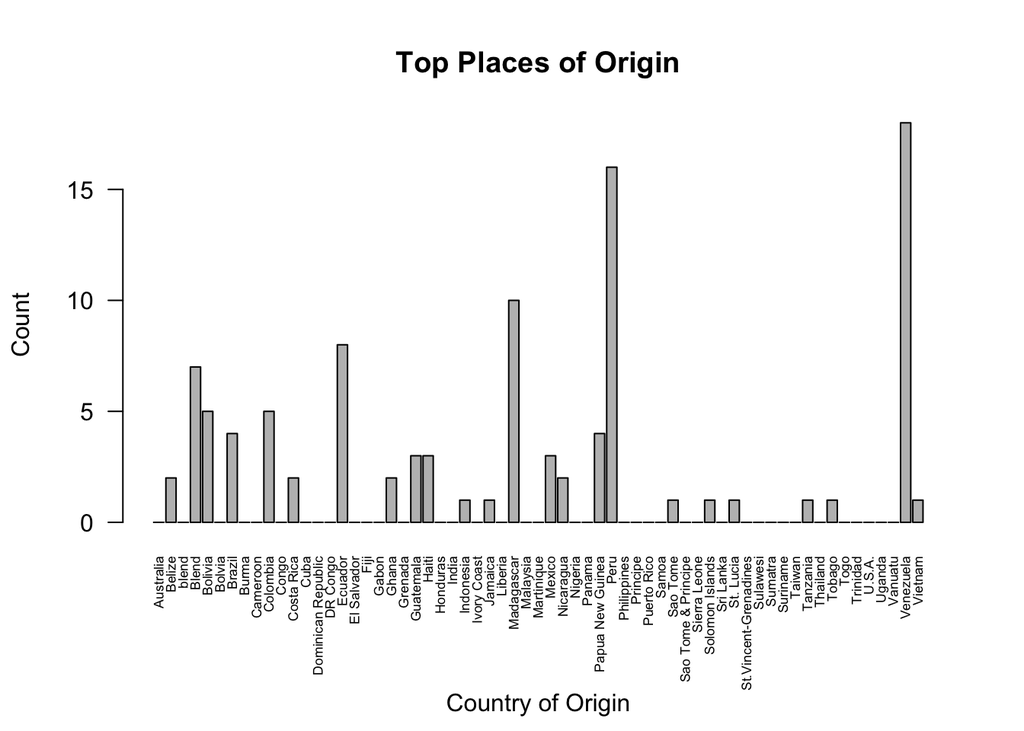

```r
par(mar=c(7, 4.2, 4.2, 2.4))
barplot(table(topO$Bean_Origin), las=2, cex.names=0.55)
title(main="Top Places of Origin", xlab="", ylab="Count")
mtext(text = 'Country of Origin',side=1, line= 5.5)
```

```r
top_origin <- sum(topO == 'Venezuela')
top_origin
```

```
## [1] 18
```

**Analysis 2:** In this analysis, I was interested to see if a certain set of ingredients tended to produce chocolate bars with higher ratings.To begin, I searched for the ingredient profiles with the most entries and subsetted a vector containing only those entries, leaving out chocolate bars with very uinque ingredient profiles. I then subsetted the dataframe to contain only those ingredient profiles. From there, I created a boxplot, showing the distributions of ratings for each ingredient profile. From the plot, Ingredient profiles 2-B,S, 3-B,S,C,and B,S,C,L tended to perform slighly better. The introduction of V,into the ingredient profile did seem to decrease the performance overall. Additionally, Ingredient profile 5- B,S,C,V,L had the highest IQR of any ingredient profile,illustrated in the summary statistics. I also included a histogram of ingredients 5- B,S,C,V,L to show its rating distributions because of its high IQR value.

```r
choco <- read.csv("https://raw.githubusercontent.com/xdaiISU/ds202materials/master/hwlabs/data/choco.csv")

sort(table(choco$Ingredients), decreasing = TRUE)
IngredientVec <- c('2- B,S','3- B,S,C','4- B,S,C,L','4- B,S,C,V','5- B,S,C,V,L')
choco.SubIngredients = choco[choco$Ingredients %in% IngredientVec ,]
choco.SubIngredients$Factor = as.factor(choco.SubIngredients$Ingredients)
```

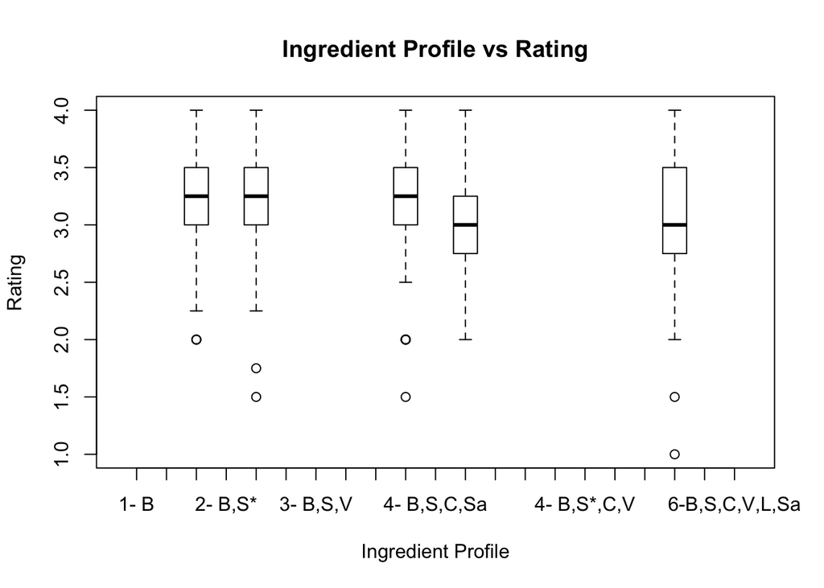

```r
boxplot(choco.SubIngredients$Rating ~ choco.SubIngredients$Factor, xlab = 'Ingredient Profile',ylab = 'Rating', main = 'Ingredient Profile vs Rating')
```

```r
summary(choco.SubIngredients$Rating[choco.SubIngredients$Ingredients == '2- B,S'])
```

```
##    Min. 1st Qu.  Median    Mean 3rd Qu.    Max.
##   2.000   3.000   3.250   3.214   3.500   4.000
```

```r
summary(choco.SubIngredients$Rating[choco.SubIngredients$Ingredients == '3- B,S,C'])
```

```
##    Min. 1st Qu.  Median    Mean 3rd Qu.    Max.
##   1.500   3.000   3.250   3.275   3.500   4.000
```

```r
summary(choco.SubIngredients$Rating[choco.SubIngredients$Ingredients == '4- B,S,C,L'])
```

```
##    Min. 1st Qu.  Median    Mean 3rd Qu.    Max.
##   1.500   3.000   3.250   3.199   3.500   4.000
```

```r
summary(choco.SubIngredients$Rating[choco.SubIngredients$Ingredients == '4- B,S,C,V'])
```

```
##    Min. 1st Qu.  Median    Mean 3rd Qu.    Max.
##   2.000   2.750   3.000   2.971   3.250   4.000
```

```r
summary(choco.SubIngredients$Rating[choco.SubIngredients$Ingredients == '5- B,S,C,V,L'])
```

```
##    Min. 1st Qu.  Median    Mean 3rd Qu.    Max.
##    1.00    2.75    3.00    3.09    3.50    4.00
```

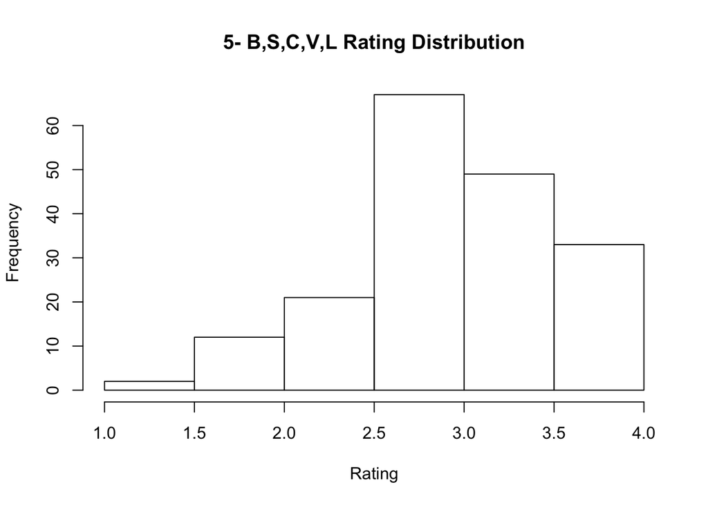

```r
bscvl<-choco[choco$Ingredients=="5- B,S,C,V,L", ]
hist(bscvl$Rating, main="5- B,S,C,V,L Rating Distribution", xlab="Rating")
```

**Analysis 3:** An analysis I made was seeing which company had the most highest rated chocolate. From my analysis, we can see that the company “Soma” has the most counts of 4.0 rated chocolate with 13 data entries. For both of these analyses, I decided to just look at the top rated chocolates so I only looked at data entries that had a 4.0 rating. This analysis suggests that the company may have an effect on the rating of chocolate, since the chocolates rated 4.0 were not distributed evenly between companies.

```r
company <- choco[c("Company", "Rating")]
topC <- company[company$Rating == 4,]
```

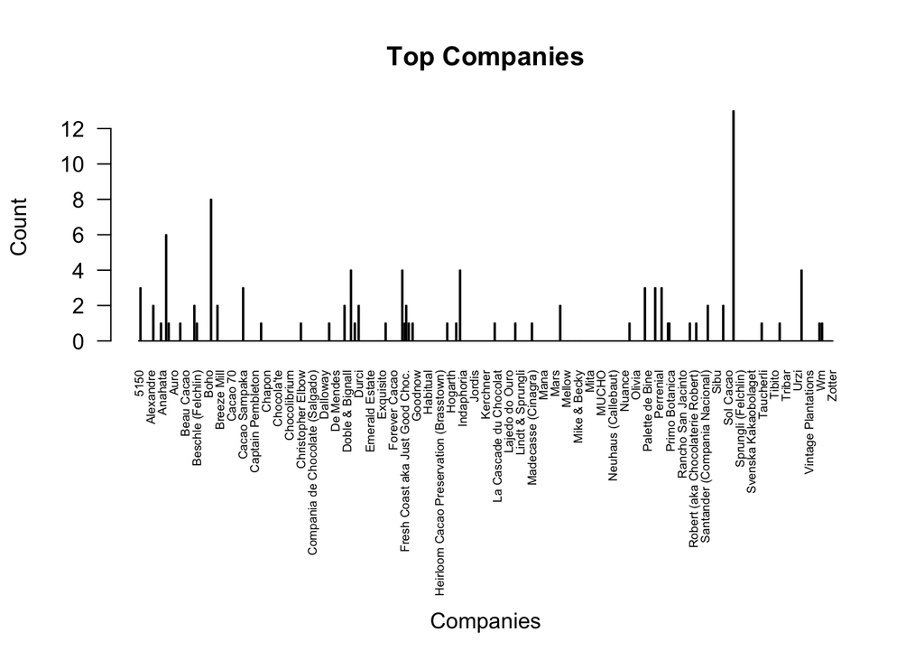

```r
par(mar=c(12, 4.2, 4.2, 2.4))
barplot(table(topC$Company), las=2, cex.names=0.55, main ='Top Companies', xlab ='', ylab = 'Count')
mtext(text = 'Companies',side=1, line= 10.0)
```

```r
top_company <- sum(topC == 'Soma')
top_company
```

```
## [1] 13
```